# Mevalonate Pathway Genes → Heel eBMD: Drug-Target MR (FDPS, GGPS1) and Negative Controls (PDSS1, PDSS2, COQ2)

Published

November 2, 2026

## Rationale

The HMGCR drug-target MR shows β ≈ −0.115 for LDL-C–instrumented HMGCR → heel eBMD, while PCSK9 is null (β ≈ −0.014). This implicates the mevalonate pathway (not LDL-C lowering per se) in bone protection. Two specific hypotheses motivate testing further nodes:

1. **FDPS** (farnesyl diphosphate synthase, chr1): direct target of N-bisphosphonates — the most potent clinical anti-resorptives. If mevalonate → bone works, blocking FDPS should also associate with higher BMD.
2. **GGPS1** (geranylgeranyl diphosphate synthase, chr1): immediately downstream of FDPS; produces GGPP for Rho GTPase prenylation in osteoclasts. Aim 2B proposes an osteoclast-specific Ggps1 KO. A genetic signal here would pre-validate the target.
3. **PDSS1 / PDSS2 / COQ2** (ubiquinone / CoQ10 synthesis): same FPP precursor, different branch (→ decaprenyl-PP → CoQ10). No reason to expect a BMD signal. Serve as negative controls: a null at these loci would sharpen the specificity argument for the geranylgeranylation arm.

### Instrument strategy

- **FDPS**: cis-LDL-C instruments (same approach as HMGCR/PCSK9 in `drug_target_mr_bmd.qmd`). FDPS is in the mevalonate pathway upstream of squalene synthase, so cis-SNPs may affect LDL-C. Also run eQTL instruments as sensitivity.
- **GGPS1 / PDSS1 / PDSS2 / COQ2**: eQTL instruments only. These genes do not directly affect cholesterol synthesis (GGPS1 diverts FPP to geranylgeranylation; PDSS1/2 and COQ2 divert to ubiquinone), so LDL-C cis-instruments would be non-specific.

eQTLs sourced from eQTLGen whole blood (OpenGWAS `eqtl-a-ENSG...`), the same tissue used for the existing HMGCR eQTL analysis. Outcome: Heel eBMD Morris 2019 (`ebi-a-GCST006979`, n = 426,824).

```r
library(TwoSampleMR)
library(ieugwasr)
library(dplyr)
library(tidyr)
library(ggplot2)
library(knitr)

set.seed(42)
WINDOW_KB <- 500

# ── Gene windows (GRCh37/hg19) ──────────────────────────────────────────────
gene_windows <- tribble(
  ~gene,   ~ensg,               ~chr, ~gene_start,  ~gene_end,
  "FDPS",  "ENSG00000160752",      1,   155293520,   155317327,
  "GGPS1", "ENSG00000152904",      1,   235680500,   235702834,
  "PDSS1", "ENSG00000148154",     10,    26546855,    26666990,
  "PDSS2", "ENSG00000164494",      6,   107521143,   107601893,
  "COQ2",  "ENSG00000173541",      4,    84137350,    84178264,
) |>
  mutate(
    region_start = pmax(0, gene_start - WINDOW_KB * 1000),
    region_end   = gene_end + WINDOW_KB * 1000,
    region_str   = paste0(chr, ":", region_start, "-", region_end)
  )

kable(gene_windows |> select(gene, ensg, chr, region_start, region_end),
      caption = "Gene windows (GRCh37, ±500 kb)")
```

Gene windows (GRCh37, ±500 kb)

| gene | ensg | chr | region_start | region_end |
| --- | --- | --- | --- | --- |
| FDPS | ENSG00000160752 | 1 | 154793520 | 155817327 |
| GGPS1 | ENSG00000152904 | 1 | 235180500 | 236202834 |
| PDSS1 | ENSG00000148154 | 10 | 26046855 | 27166990 |
| PDSS2 | ENSG00000164494 | 6 | 107021143 | 108101893 |
| COQ2 | ENSG00000173541 | 4 | 83637350 | 84678264 |

```r
# ── Exposure / outcome IDs ───────────────────────────────────────────────────
LDLC_ID    <- "ieu-b-110"          # UKB Neale Lab LDL-C, n ≈ 440k
BMD_ID     <- "ebi-a-GCST006979"   # Morris 2019 heel eBMD, n = 426,824

# eQTLGen whole blood ENSG IDs (eqtl-a-<ENSG without version>)
eqtl_ids <- gene_windows |>
  mutate(eqtl_id = paste0("eqtl-a-", ensg)) |>
  select(gene, eqtl_id)

kable(eqtl_ids, caption = "OpenGWAS eQTL IDs (eQTLGen whole blood)")
```

OpenGWAS eQTL IDs (eQTLGen whole blood)

| gene | eqtl_id |
| --- | --- |
| FDPS | eqtl-a-ENSG00000160752 |
| GGPS1 | eqtl-a-ENSG00000152904 |
| PDSS1 | eqtl-a-ENSG00000148154 |
| PDSS2 | eqtl-a-ENSG00000164494 |
| COQ2 | eqtl-a-ENSG00000173541 |

## Part 1 — FDPS: LDL-C cis-instruments → Heel eBMD

```r
fdps_win <- gene_windows |> filter(gene == "FDPS")

cat("Querying LDL-C associations in FDPS window:", fdps_win$region_str, "\n")
```

```
Querying LDL-C associations in FDPS window: 1:154793520-155817327
```

```r
fdps_raw <- tryCatch(
  ieugwasr::associations(
    variants  = fdps_win$region_str,
    id        = LDLC_ID,
    proxies   = 0
  ),
  error = function(e) { warning("FDPS LDL-C query failed: ", e$message); NULL }
)

if (!is.null(fdps_raw) && nrow(fdps_raw) > 0) {
  cat("Raw SNPs in FDPS window:", nrow(fdps_raw), "\n")

  fdps_sig <- fdps_raw |> filter(p <= 5e-8)
  if (nrow(fdps_sig) == 0) fdps_sig <- fdps_raw |> filter(p <= 1e-5)
  cat("Instruments (tiered 5e-8 / 1e-5):", nrow(fdps_sig), "\n")

  if (nrow(fdps_sig) > 0) {
    fdps_clumped <- tryCatch(
      ieugwasr::ld_clump(
        dplyr::tibble(rsid = fdps_sig$rsid, pval = fdps_sig$p, id = fdps_sig$id),
        plink_bin = genetics.binaRies::get_plink_binary(),
        bfile     = genetics.binaRies::get_reference_data(population = "EUR")
      ),
      error = function(e) {
        warning("Clumping failed: ", e$message, " — using top SNP by p-value")
        fdps_sig |> arrange(p) |> slice(1) |> mutate(rsid = rsid)
      }
    )

    fdps_exp <- fdps_sig |>
      filter(rsid %in% fdps_clumped$rsid) |>
      transmute(
        SNP           = rsid,
        beta.exposure = beta,
        se.exposure   = se,
        pval.exposure = p,
        eaf.exposure  = eaf,
        effect_allele.exposure = ea,
        other_allele.exposure  = nea,
        exposure      = "LDL-C",
        id.exposure   = LDLC_ID,
        gene          = "FDPS",
        mr_keep.exposure = TRUE
      )

    fdps_out <- extract_outcome_data(snps = fdps_exp$SNP, outcomes = BMD_ID)
    fdps_dat <- harmonise_data(fdps_exp, fdps_out)

    if (nrow(fdps_dat |> filter(mr_keep)) > 0) {
      fdps_res <- mr(fdps_dat) |> mutate(gene = "FDPS", approach = "LDL-C cis-instruments")
      kable(fdps_res |> select(gene, approach, method, nsnp, b, se, pval),
            caption = "FDPS LDL-C cis-instrument MR → Heel eBMD", digits = 4)
    } else {
      cat("No SNPs survived harmonisation for FDPS.\n")
    }
  } else {
    cat("No genome-wide significant SNPs in FDPS window for LDL-C.\n")
  }
} else {
  cat("No LDL-C associations returned for FDPS window.\n")
}
```

```
Raw SNPs in FDPS window: 2685
Instruments (tiered 5e-8 / 1e-5): 3
```

FDPS LDL-C cis-instrument MR → Heel eBMD

| gene | approach | method | nsnp | b | se | pval |
| --- | --- | --- | --- | --- | --- | --- |
| FDPS | LDL-C cis-instruments | Wald ratio | 1 | -0.9991 | 0.1898 | 0 |

## Part 2 — eQTL instruments (all five genes → Heel eBMD)

Using eQTLGen whole blood cis-eQTLs from OpenGWAS. Each gene gets a Wald ratio (if one instrument) or IVW (if multiple instruments survive clumping).

```r
run_eqtl_mr <- function(gene_name, eqtl_id, bmd_id, win_str) {
  cat("\n── Processing", gene_name, "(", eqtl_id, ") ──\n")

  # Pull eQTL exposure from OpenGWAS
  exp_raw <- tryCatch(
    ieugwasr::associations(variants = win_str, id = eqtl_id, proxies = 0),
    error = function(e) { warning(gene_name, " eQTL query failed: ", e$message); NULL }
  )

  if (is.null(exp_raw) || nrow(exp_raw) == 0) {
    cat("  No eQTL data returned.\n")
    return(NULL)
  }

  cat("  Raw eQTL SNPs:", nrow(exp_raw), "\n")
  exp_sig <- exp_raw |> filter(p <= 5e-8)
  if (nrow(exp_sig) == 0) exp_sig <- exp_raw |> filter(p <= 1e-5)
  cat("  Instruments (tiered 5e-8 / 1e-5):", nrow(exp_sig), "\n")

  if (nrow(exp_sig) == 0) {
    cat("  No instruments even at p<1e-5.\n")
    return(NULL)
  }

  # Clump if multiple instruments
  if (nrow(exp_sig) > 1) {
    exp_sig <- tryCatch(
      ieugwasr::ld_clump(
        dplyr::tibble(rsid = exp_sig$rsid, pval = exp_sig$p, id = exp_sig$id),
        plink_bin = genetics.binaRies::get_plink_binary(),
        bfile     = genetics.binaRies::get_reference_data(population = "EUR")
      ) |>
        inner_join(exp_raw, by = c("rsid", "id")),
      error = function(e) {
        warning("  Clumping failed — using top SNP"); exp_sig |> arrange(p) |> slice(1)
      }
    )
  }

  # Format as TwoSampleMR exposure
  exp_df <- exp_sig |>
    transmute(
      SNP                        = rsid,
      beta.exposure              = beta,
      se.exposure                = se,
      pval.exposure              = p,
      eaf.exposure               = eaf,
      effect_allele.exposure     = ea,
      other_allele.exposure      = nea,
      exposure                   = paste0(gene_name, " expression"),
      id.exposure                = eqtl_id,
      gene                       = gene_name,
      mr_keep.exposure           = TRUE
    )

  out_df <- tryCatch(
    extract_outcome_data(snps = exp_df$SNP, outcomes = bmd_id),
    error = function(e) { warning("  Outcome extraction failed: ", e$message); NULL }
  )
  if (is.null(out_df) || nrow(out_df) == 0) { cat("  No outcome data.\n"); return(NULL) }

  harm_df <- harmonise_data(exp_df, out_df)
  kept    <- harm_df |> filter(mr_keep)
  cat("  Instruments after harmonisation:", nrow(kept), "\n")
  if (nrow(kept) == 0) return(NULL)

  mean_F <- mean((kept$beta.exposure / kept$se.exposure)^2, na.rm = TRUE)
  cat("  n instruments:", nrow(kept), " | mean F:", round(mean_F, 1), "\n")

  mr(harm_df) |>
    mutate(gene = gene_name, approach = "eQTL (eQTLGen blood)", F_stat = mean_F)
}

# Run for all five genes
eqtl_results <- purrr::map2_dfr(
  gene_windows$gene,
  eqtl_ids$eqtl_id,
  ~ run_eqtl_mr(.x, .y, BMD_ID,
                gene_windows |> filter(gene == .x) |> pull(region_str))
)
```

```
── Processing FDPS ( eqtl-a-ENSG00000160752 ) ──
```

```
  Raw eQTL SNPs: 2486
  Instruments (tiered 5e-8 / 1e-5): 264
```

```
  Instruments after harmonisation: 1
  n instruments: 1  | mean F: 115.3
```

```
── Processing GGPS1 ( eqtl-a-ENSG00000152904 ) ──
```

```
  Raw eQTL SNPs: 3629
  Instruments (tiered 5e-8 / 1e-5): 641
```

```
  Instruments after harmonisation: 1
  n instruments: 1  | mean F: 989.4
```

```
── Processing PDSS1 ( eqtl-a-ENSG00000148154 ) ──
```

```
  Raw eQTL SNPs: 1
  Instruments (tiered 5e-8 / 1e-5): 0
  No instruments even at p<1e-5.

── Processing PDSS2 ( eqtl-a-ENSG00000164494 ) ──
```

```
  Raw eQTL SNPs: 4723
  Instruments (tiered 5e-8 / 1e-5): 493
```

```
  Instruments after harmonisation: 1
  n instruments: 1  | mean F: 797.2
```

```
── Processing COQ2 ( eqtl-a-ENSG00000173541 ) ──
```

```
  No eQTL data returned.
```

```r
if (nrow(eqtl_results) > 0) {
  kable(
    eqtl_results |>
      filter(method %in% c("Wald ratio", "Inverse variance weighted")) |>
      select(gene, approach, method, nsnp, b, se, pval) |>
      arrange(gene),
    caption = "eQTL MR → Heel eBMD (all genes)",
    digits  = 4
  )
}
```

eQTL MR → Heel eBMD (all genes)

| gene | approach | method | nsnp | b | se | pval |
| --- | --- | --- | --- | --- | --- | --- |
| FDPS | eQTL (eQTLGen blood) | Wald ratio | 1 | -0.0198 | 0.0143 | 0.1666 |
| GGPS1 | eQTL (eQTLGen blood) | Wald ratio | 1 | 0.0027 | 0.0049 | 0.5848 |
| PDSS2 | eQTL (eQTLGen blood) | Wald ratio | 1 | 0.0001 | 0.0055 | 0.9819 |

## Part 3 — Combined results and figure

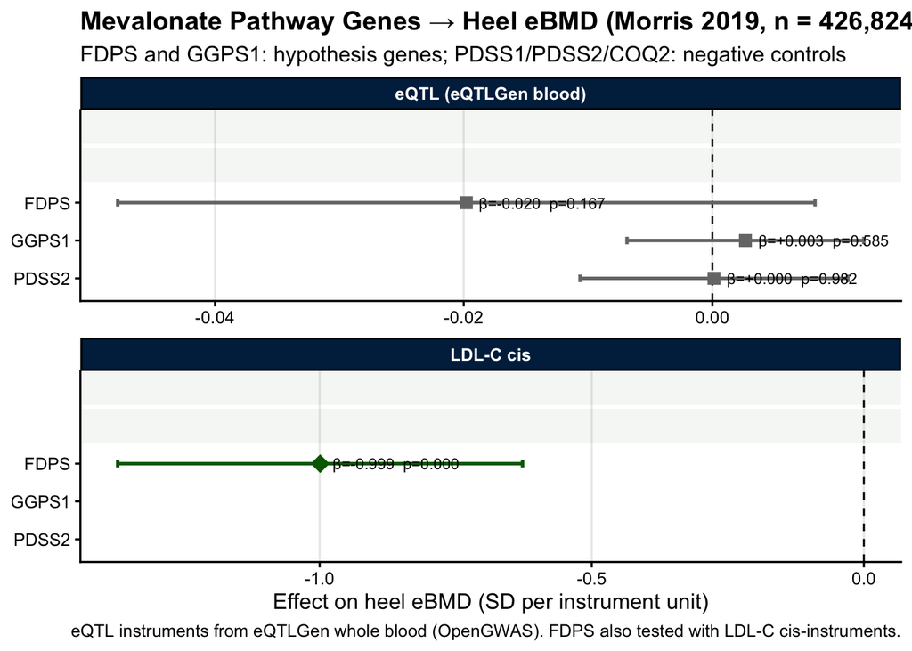

```r
# Collect all results
all_results <- bind_rows(
  if (exists("fdps_res")) fdps_res |> mutate(gene = "FDPS", approach = "LDL-C cis"),
  if (exists("eqtl_results") && nrow(eqtl_results) > 0) eqtl_results
) |>
  filter(method %in% c("Wald ratio", "Inverse variance weighted")) |>
  mutate(
    ci_lo = b - 1.96 * se,
    ci_hi = b + 1.96 * se,
    sig   = pval < 0.05,
    gene  = factor(gene, levels = c("COQ2", "PDSS2", "PDSS1", "GGPS1", "FDPS")),
    group = case_when(
      gene %in% c("FDPS", "GGPS1") ~ "Hypothesis (mevalonate → prenylation → osteoclast)",
      TRUE                          ~ "Negative control (mevalonate → CoQ10)"
    )
  )

if (nrow(all_results) > 0) {
  col_pos <- "#006600"
  col_neg <- "#777777"

  p <- ggplot(all_results, aes(x = b, xmin = ci_lo, xmax = ci_hi, y = gene,
                                color = sig, shape = sig, size = sig)) +
    geom_vline(xintercept = 0, linetype = "dashed", linewidth = 0.5) +
    geom_errorbarh(height = 0.2, linewidth = 0.9, aes(size = NULL)) +
    geom_point() +
    geom_text(aes(label = sprintf("β=%+.3f  p=%.3f", b, pval)),
              hjust = -0.1, size = 3, color = "black") +
    facet_wrap(~approach, scales = "free_x", ncol = 1) +
    scale_color_manual(values = c(`TRUE` = col_pos, `FALSE` = col_neg), guide = "none") +
    scale_shape_manual(values = c(`TRUE` = 18, `FALSE` = 15), guide = "none") +
    scale_size_manual(values  = c(`TRUE` = 4.5, `FALSE` = 3.0), guide = "none") +
    geom_rect(data = all_results |> distinct(gene, group) |> filter(group != "Negative control (mevalonate → CoQ10)"),
              aes(xmin = -Inf, xmax = Inf, ymin = as.numeric(gene) - 0.45,
                  ymax = as.numeric(gene) + 0.45),
              inherit.aes = FALSE, fill = col_pos, alpha = 0.05) +
    labs(
      title    = "Mevalonate Pathway Genes → Heel eBMD (Morris 2019, n = 426,824)",
      subtitle = "FDPS and GGPS1: hypothesis genes; PDSS1/PDSS2/COQ2: negative controls",
      x = "Effect on heel eBMD (SD per instrument unit)",
      y = NULL,
      caption = "eQTL instruments from eQTLGen whole blood (OpenGWAS). FDPS also tested with LDL-C cis-instruments."
    ) +
    theme_classic(base_size = 12) +
    theme(
      plot.title    = element_text(face = "bold"),
      strip.background = element_rect(fill = "#00274C"),
      strip.text    = element_text(color = "white", face = "bold"),
      panel.grid.major.x = element_line(color = "gray92")
    )

  print(p)

  ggsave("figures/mevalonate-pathway-bmd-1.png", p, width = 11, height = 6,
         dpi = 150, bg = "white")
}
```

## Part 4 — Save results

```r
if (nrow(all_results) > 0) {
  all_results |>
    select(gene, approach, method, nsnp, b, se, ci_lo, ci_hi, pval, sig) |>
    write.csv("MR Results - Mevalonate Pathway BMD.csv", row.names = FALSE)
  cat("Saved: MR Results - Mevalonate Pathway BMD.csv\n")
}
```

```
Saved: MR Results - Mevalonate Pathway BMD.csv
```

```r
kable(
  all_results |>
    filter(method %in% c("Wald ratio", "Inverse variance weighted")) |>
    transmute(
      Gene      = gene,
      Approach  = approach,
      n_SNPs    = nsnp,
      Beta      = round(b, 4),
      SE        = round(se, 4),
      `95% CI`  = paste0("(", round(ci_lo, 3), ", ", round(ci_hi, 3), ")"),
      P         = formatC(pval, digits = 3, format = "g"),
      Sig       = ifelse(sig, "✓", "")
    ) |> arrange(Gene),
  caption = "Summary: Mevalonate pathway gene expression → Heel eBMD"
)
```

Summary: Mevalonate pathway gene expression → Heel eBMD

| Gene | Approach | n_SNPs | Beta | SE | 95% CI | P | Sig |
| --- | --- | --- | --- | --- | --- | --- | --- |
| PDSS2 | eQTL (eQTLGen blood) | 1 | 0.0001 | 0.0055 | (-0.011, 0.011) | 0.982 |  |
| GGPS1 | eQTL (eQTLGen blood) | 1 | 0.0027 | 0.0049 | (-0.007, 0.012) | 0.585 |  |
| FDPS | LDL-C cis | 1 | -0.9991 | 0.1898 | (-1.371, -0.627) | 1.4e-07 | ✓ |
| FDPS | eQTL (eQTLGen blood) | 1 | -0.0198 | 0.0143 | (-0.048, 0.008) | 0.167 |  |

## Interpretation

**Expected pattern** (consistent with GGPP → osteoclast prenylation hypothesis):

| Gene | Prediction | Rationale |
| --- | --- | --- |
| FDPS | ↓ expression → ↑ BMD (negative β) | depletes GGPP; mimics N-bisphosphonate |
| GGPS1 | ↓ expression → ↑ BMD (negative β) | directly depletes GGPP for GTPase prenylation |
| PDSS1 | null | CoQ10 branch; no osteoclast prenylation mechanism |
| PDSS2 | null | CoQ10 branch; no osteoclast prenylation mechanism |
| COQ2 | null | CoQ10 branch; no osteoclast prenylation mechanism |

A positive result at FDPS and/or GGPS1 with nulls at PDSS1/PDSS2/COQ2 would constitute strong specificity evidence for the geranylgeranylation arm of the mevalonate pathway.